# Exponential Distributions vs the Central Limit Theorem

Nils Sandøy

August 19, 2015

This is a course project for the Coursera class in Statistical Inference. The goal of this project is to investigate the [Exponential Distribution](https://en.wikipedia.org/wiki/Exponential_distribution) and make a comparison with the [Central Limit Theorem (CLM)](https://en.wikipedia.org/wiki/Central_limit_theorem).

**Assignment:** > Illustrate via simulation and associated explanatory text the properties of the distribution of the mean of 40 exponentials. You should > 1. Show the sample mean and compare it to the theoretical mean of the distribution. > 2. Show how variable the sample is (via variance) and compare it to the theoretical variance of the distribution. > 3. Show that the distribution is approximately normal.

The **CLT** states that the distribution of averages of **independent** and **identically** **distributed** (**iid**) variables (properly normalized) becomes that of a standard normal as the sample size increases. The result is The result is that $\frac{\bar X_n - \mu}{\sigma / \sqrt{n}}= \frac{\sqrt n (\bar X_n - \mu)}{\sigma} = \frac{\mbox{Estimate} - \mbox{Mean of estimate}}{\mbox{Std. Err. of estimate}}$ has a distribution like that of a standard normal for large $n$. A useful way to think about the CLT is that $\bar X_n$ is approximately $N(\mu, \sigma^2 / n)$

The **Exponental Distribution** is the probability distribution that describes the time between events in a **Poisson process**, in which events occur continuosly and independently at a constant average rate.

The **probability desity function** (PDF) of an exponential function is $f(x;\lambda)=\begin{Bmatrix} \lambda \mathrm{e}^{-\lambda x} & x>=0. \\ 0 & x<0. \end{Bmatrix}$

The mean or expected value of an exponential distribution is $E[X] = \frac{1}{\lambda} = \beta$

The standard deviation ($\sigma$) is equal to the mean ($\frac{1}{\lambda}$), as the variance of $X$ is given by $Var[X] = \frac{1}{\lambda^2}$

The exponential distribution with rate $\lambda$ has density $f(x)=\lambda{\mathrm{e}}^{-\lambda x}$

$\lambda$ is set to **0.2** for all simulations. I will investigate the distribution of averages of 40 exponentials and do a thousand simulations.

## Example exponential distribution with $n=40$

```r
lambda <- 0.2
n <- 40

# Example exponential distribution
ed1 <- rexp(n,lambda)
ed1
```

```
##  [1]  8.15710826 18.57101448  3.79340926  2.46957961  0.78753359
##  [6]  2.01147658 13.45571841  6.61320197  1.03463201  0.85300023
## [11]  0.29065185  5.11814618  0.35431706  0.55688847 15.23540102
## [16]  4.89884697  1.00296092  3.16520132  2.08175132  0.02753640
## [21]  6.76172523  2.93539886  2.30703992 14.82805710 10.04313844
## [26]  6.22164027  1.05724566  0.96777423  6.50668009  0.01135577
## [31]  4.10467517  1.13156306  8.20268351  1.18123795  1.59296620
## [36]  4.61871482 10.41971260  0.01880260  4.66811805 12.38392680
```

```r
#sample mean
mean(ed1)
```

```
## [1] 4.761021
```

```r
#Theoretical mean
1/lambda
```

```
## [1] 5
```

## Illustration of the properties of the distribution of the mean of exponentials.

### **Assignment:**

> Illustrate via simulation and associated explanatory text the properties of the distribution of the mean of 40 exponentials.

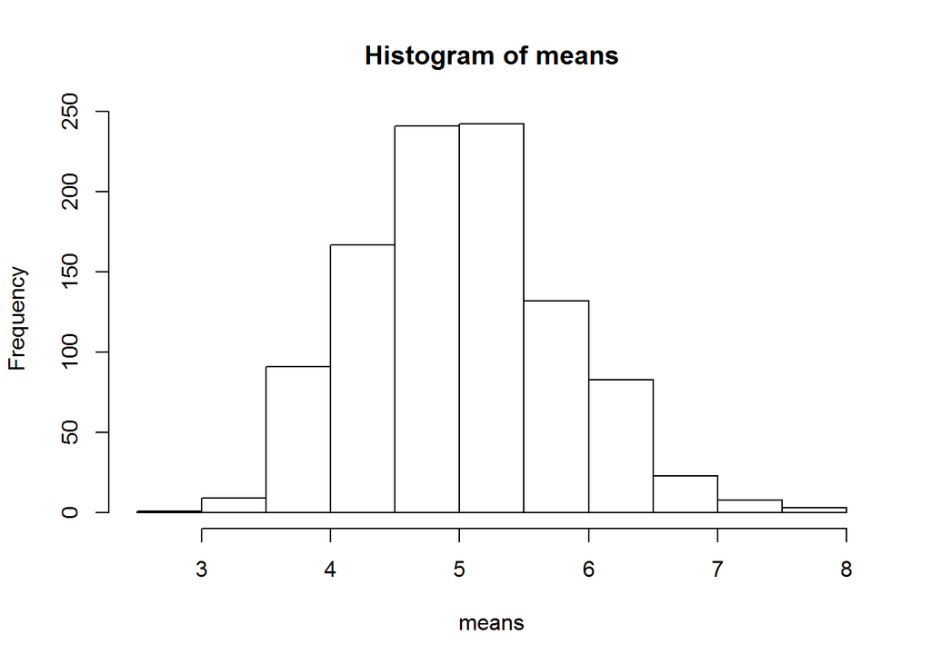

```r
lambda <- 0.2
n <- 40
theoretical_mean <- 1/lambda
theoretical_variance <- 1/(lambda^2)
nosim <- 1000

exp_dist <- function(i, n, rate) rexp(n, rate)

dist <- matrix(data = apply(matrix(1:nosim), MARGIN=1, FUN=exp_dist, n, lambda), nrow = nosim, ncol=n)
means <-apply(dist, MARGIN=1, FUN=mean)
variances <- apply(dist, MARGIN=1, FUN=var)

sample_mean <- mean(means)
sample_variance <- mean(variances)

hist(means)
```

A simple histogram over the 1000 simulations, each of 40 values, does show that the distribution of the mean of these exponentials does cluster around the theorectical mean of 5

### 1. Show the sample mean and compare it to the theoretical mean of the distribution.

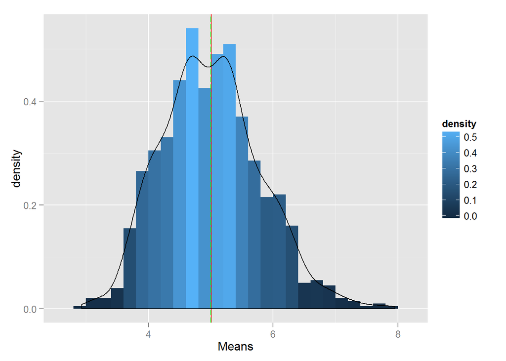

```r
library(ggplot2)

dat <- data.frame(Means = c(means))

g <- ggplot(dat, aes(x = Means)) +
    geom_histogram(binwidth=0.2, aes(y = ..density.., fill=..density..))
g <- g + geom_vline(xintercept=sample_mean, color="red")
g <- g + geom_vline(xintercept=theoretical_mean, color="green", linetype="longdash")
g <- g + geom_density()
plot(g)
```

The sample mean, **5.0091067**, is here shown in red. It is very close to the theoretical mean of **5** shown in green. This does correspond with the CLT which predicts that the sample mean will approximate the theoretical mean when we do many simulations

### 2. Show how variable the sample is (via variance) and compare it to the theoretical variance of the distribution.

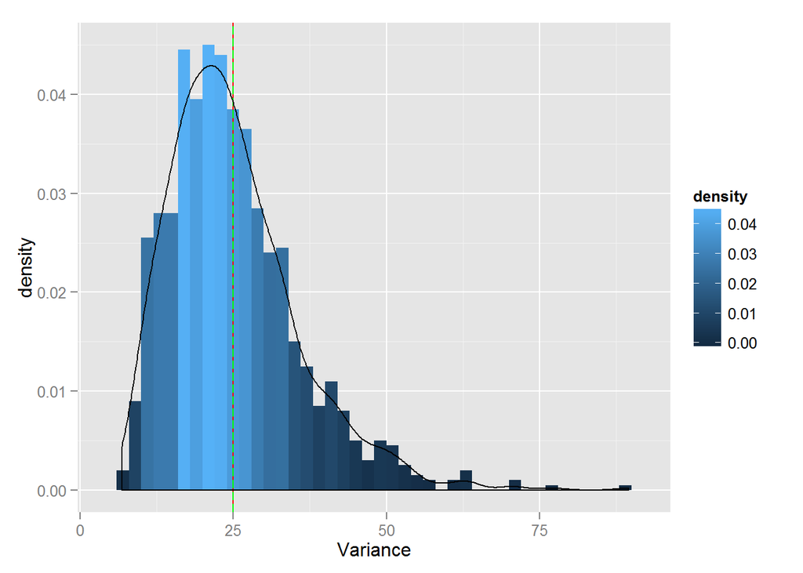

```r
library(ggplot2)

dat <- data.frame(Variance = c(variances))

g <- ggplot(dat, aes(x = Variance)) +
    geom_histogram(binwidth=2, aes(y = ..density.., fill=..density..))
g <- g + geom_vline(xintercept=sample_variance, color="red")
g <- g + geom_vline(xintercept=theoretical_variance, color="green", linetype="longdash")
g <- g + geom_density()
plot(g)
```

### 3. Show that the distribution is approximately normal.

A random variable is said to follow a **normal** or **[Gausian](https://en.wikipedia.org/wiki/Normal_distribution)** distribution with mean $\mu$ and variance $\sigma^2$ if the associated density is: $(2\pi\sigma^2)^{-\frac{1}{2}}e^{\frac{-(x-\mu)^2}{2\sigma^2}}$

Focus on the difference between the distribution of a large collection of random exponentials and the distribution of a large collection of averages of 40 exponentials.

#### Comparison of random exponentials vs averages of smaller sets of exponentals with the normal distribution

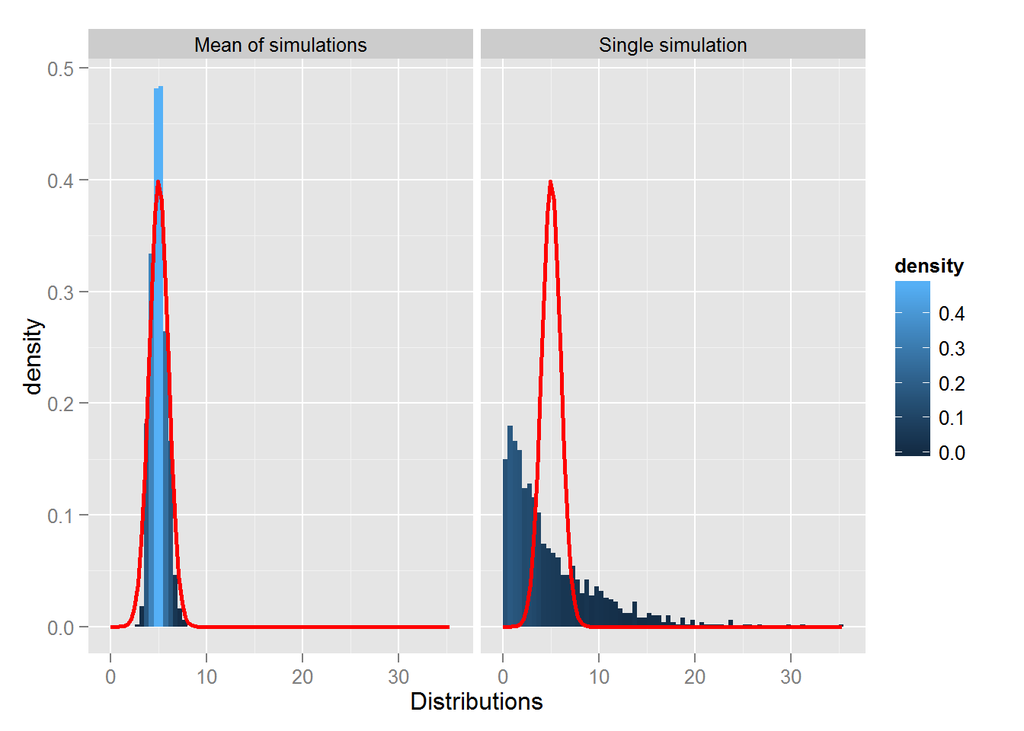

```r
library(ggplot2)

sample_dist <- c(rexp(nosim, lambda))

dat <- data.frame(Distributions=c(sample_dist, means),
                  type = factor(rep(c("Single simulation", "Mean of simulations"), rep(nosim, 2))))

g <- ggplot(dat, aes(x = Distributions)) +
    geom_histogram(binwidth=.5, aes(y = ..density.., fill=..density..)) +
    stat_function(fun = dnorm, size = 1, color="red", args=list(mean=theoretical_mean)) +
    facet_grid(. ~ type)

plot(g)
```

It is clear that the distribution of the means of 1000 distribution with $n=$ 40, is more “bell shaped” than the straight exponential distribution of 1000 elements. This is even clearer when we compare the distribution of the means against the normal distribution:

#### Plot of the means

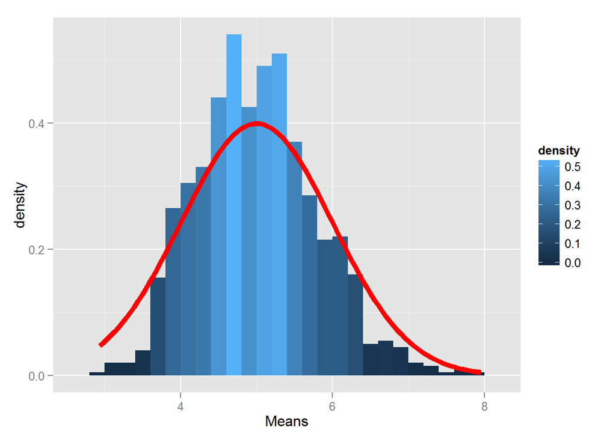

```r
library(ggplot2)

dat <- data.frame(Means=c(means))

g <- ggplot(dat, aes(x = Means)) +
    geom_histogram(binwidth=.2, aes(y = ..density.., fill=..density..)) +
        stat_function(fun = dnorm, size = 2, color="red", args=list(mean=theoretical_mean))
plot(g)
```